# Kunal Palawat Final December 11, 2017

Set Working Directory. Change this location if not using Kunal’s Laptop.

```r
setwd("~/Desktop/UVM/3rd Year/Fall Semester/PBIO294")
```

1. (30 points) An ecologist is interested in the intermediate disturbance hypothesis (IDH) that postulates that the highest species richness should be found at intermediate levels of disturbance. Write a likelihood function to estimate the  
   parameters for a quadratic regression models given in Beckage and Stout 2000 (http://www.uvm.edu/~bbeckage/Manuscripts/BeckageStout.corrected.2000.jvs.pdf), but assuming a Poisson likelihood with a log link function.

The data may be read using:

|  | sr | nFires |
| --- | --- | --- |
| 1 | 16 | 1 |
| 2 | 13 | 1 |
| 3 | 11 | 1 |
| 4 | 13 | 1 |
| 5 | 13 | 1 |
| 6 | 14 | 1 |
| 7 | 12 | 1 |
| 8 | 8 | 1 |
| 9 | 9 | 1 |
| 10 | 11 | 1 |

[output cut: 290 more lines]

Likelihood Function

```r
nllPoi=function(parVec, burns, sr){
    b0=parVec[1]
    b1=parVec[2]
    b2=parVec[3]
  yHat=exp(b0+b1*burns+b2*burns^2)
  nllik=-sum(dpois(x=sr,lambda=yHat,log=TRUE))
  return(nllik)
  return(yHat)
}
```

Initialize Betas

```r
parVec=c(.1, .1, .1)
```

Obtain MLEs for betas. Obtain nll value.

```r
outPois=optim(par=parVec,fn=nllPoi,method="L-BFGS-B",lower=c(-Inf,-Inf),upper=c(Inf,Inf), burns=srDat$nFires, sr=srDat$sr)
outPois$par
```

```
[1]  2.05578969  0.44405624 -0.04586403
```

```r
outPois$val
```

```
[1] 848.0213
```

Simulate data from regression parameters.

```r
yHat=exp( 2.05578969+0.44405624*burns+-0.04586403*burns^2)
```

Plot line of best fit from the simulated data over scatterplot of data.

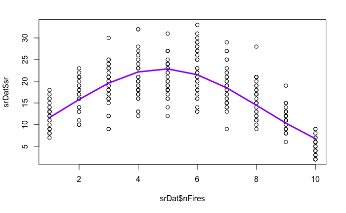

2. (30 points) Repeat exercise 1 except now fitting the model using either Rstan or Rjags. You must write your own Stan/JAGS model, meaning that you can not use one of the Stan helper libraries such as the brms or rstanarm libraries.

Write Model String in JAGS to a text file.

```r
library(rjags)

modelString<-"
model {
  for (i in 1:N){
    yHat[i] ~ dpois(p[i])
    log(p[i]) <- beta0 + beta1*burns[i] + beta2*burns[i]^2
  }
  beta0 ~ dnorm(0, .0001)
  beta1 ~ dnorm(0, .0001)
  beta2 ~ dnorm(0, .0001)
}
"
writeLines(modelString, con='burnsReg.jags.txt')
```

Run the model string in JAGS and initialize the four chains. If more chains are wanted, change the “n.chains” number and add the appropriate number of lists of initial paramter values.

```r
jags <- jags.model('burnsReg.jags.txt',
                   data = list('yHat' = srDat$sr,
                               'burns' = srDat$nFires,
                               'N' = length(srDat$nFires)),
                   inits<-list(
                       list('beta0'=2,'beta1'=.4, 'beta2'=1),
                       list('beta0'=4,'beta1'=1, 'beta2'=-1),
                       list('beta0'=1,'beta1'=1, 'beta2'=1),
                       list('beta0'=2,'beta1'=.4, 'beta2'=-1)),
                   n.chains = 4,
                   n.adapt = 100)
```

[output not shown]

Update Model and sample.

```r
update(jags, 1000)
```

[output not shown]

```r
jags.samples(jags,
             c('beta0', 'beta1', 'beta2'),
             10000)
```

[output not shown]

[output cut: 12 more lines]

```
[1] 2.070208

Marginalizing over: iteration(10000),chain(4)

$beta1
mcarray:
[1] 0.4370874

Marginalizing over: iteration(10000),chain(4)

$beta2
mcarray:
[1] -0.0452134

Marginalizing over: iteration(10000),chain(4)
```

Use coda library to sample and plot data.

```r
library(coda)
codaSamples<-coda.samples(jags, c('beta0','beta1', 'beta2'), 10000, 1)
```

[output not shown]

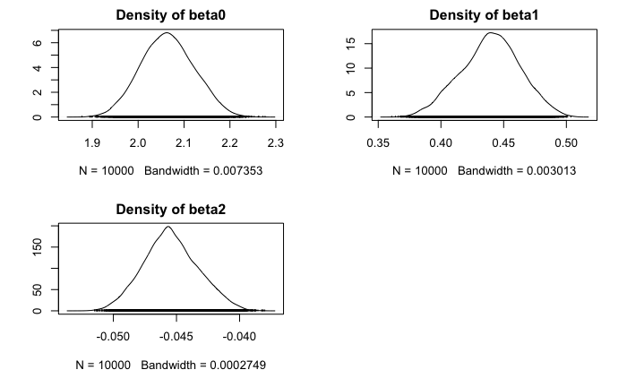

```r
plot(codaSamples, trace = FALSE, density = TRUE)
```

```r
summary(codaSamples)
```

```
Iterations = 11101:21100
Thinning interval = 1
Number of chains = 4
Sample size per chain = 10000

1. Empirical mean and standard deviation for each variable,
   plus standard error of the mean:

          Mean       SD  Naive SE Time-series SE
beta0  2.06438 0.057751 2.888e-04      0.0030430
beta1  0.43960 0.023661 1.183e-04      0.0014687
beta2 -0.04544 0.002167 1.084e-05      0.0001276

2. Quantiles for each variable:

          2.5%     25%      50%      75%    97.5%
beta0  1.95392  2.0241  2.06335  2.10370  2.17786
beta1  0.39215  0.4238  0.44038  0.45580  0.48474
beta2 -0.04956 -0.0469 -0.04553 -0.04401 -0.04105
```

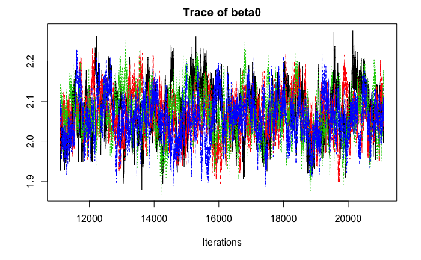

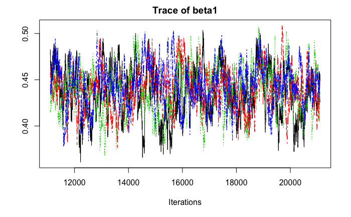

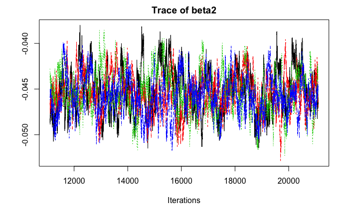

```r
traceplot(codaSamples)
```

Run gelman.diag which asseses convergence. Values less than 1.1 are typically seen as good, values above indicate that the chains have not converged. Run gelman.plot which shows how converged the chains are over the sampling period. These statistics indicate that beta0, beta1, and beta2 are converged.

```r
gelman.diag(codaSamples, confidence=.95)
```

```
Potential scale reduction factors:

      Point est. Upper C.I.
beta0       1.01       1.03
beta1       1.02       1.05
beta2       1.02       1.05

Multivariate psrf

1.01
```

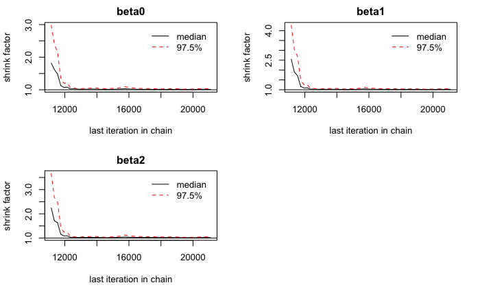

```r
gelman.plot(codaSamples, confidence=.95)
```

Read data and assign different parts of the data frame to variables. JAGS does not appreciate when I use seedDF$ in the code.

```r
seedDF<-read.table("http://www.uvm.edu/~bbeckage/Teaching/PBIO_294/Data/seeds.csv",sep=',',header=TRUE)
mass=seedDF$mass
seedLost=seedDF$seedLost
gap=seedDF$gap
```

```r
library(rjags)
seedList=list(seedLost=seedLost,mass=mass,N=length(mass), gap=gap)
modelString="
model{
    for (i in 1:N) {
      seedLost[i] ~ dbern(theta[i])
      logit(theta[i]) = beta0[i] + beta1*gap[i]
      beta0[i] ~ dgamma(mu[i]^2/var,mu[i]/var)
      log(mu[i]) = beta2 + beta3*mass[i] - beta4*(mass[i])^2
    }

  #priors
    variance ~ dgamma(0.001,0.001)
    beta1 ~ dnorm(0,100)
    beta2 ~ dnorm(0,100)
    beta3 ~ dnorm(0,100)
    beta4 ~ dnorm(0,100)
  }
"
writeLines (modelString, con="Finalmodel.txt")
```

Write JAGS model, initialize paramters, and update model with burn in, which is 1000.

```r
require(rjags)
jagsModel=jags.model("Finalmodel.txt",
                     data=seedList,
                     inits= list(
                       list('beta1'=2,'beta2'=.4, 'beta3'=1, 'beta4'=1),
                       list('beta1'=4,'beta2'=1, 'beta3'=-1, 'beta4'=1),
                       list('beta1'=1,'beta2'=1, 'beta3'=1, 'beta4'=1),
                       list('beta1'=2,'beta2'=.4, 'beta3'=-1, 'beta4'=1)),
                   n.chains = 4,
                   n.adapt = 100)
```

[output not shown]

```r
burnInSteps=1000
update(jagsModel, n.inter=burnInSteps)
```

Run model, obtain summaries and traceplots of betas. Plots for each iteration can be published, but that code has been commented out for now due to the long runtime. The percentiles are reported in addition to beta means, SD, and SE. The trace plots indicate that more interations need to be run for the values to visually converge. To obtain more accurate measurements of convergence, run gelman diagnostics on the chains as done in the next chunk.

```r
require(coda)
codaSamples=coda.samples(jagsModel, variable.names = c("beta1", "beta2", "beta3", "beta4"), n.iter=10000, thin=10)
```

[output not shown]

```r
#plot(codaSamples, trace=FALSE, density=TRUE)
HPDinterval(codaSamples)
```

```
[[1]]
            lower         upper
beta1  0.84740844  1.127018e+00
beta2 -0.25676794  1.662008e-01
beta3 -0.54297570 -1.687634e-01
beta4 -0.02636244  2.270854e-05
attr(,"Probability")
[1] 0.95

[[2]]
            lower         upper
beta1  0.85455496  1.1303714608
beta2 -0.24854161  0.1210324834
beta3 -0.49147946 -0.1712093925
beta4 -0.02360036  0.0001300263
attr(,"Probability")
[1] 0.95

[[3]]
            lower        upper
beta1  0.86911830  1.138720746
beta2 -0.27068240  0.101051500
beta3 -0.52733494 -0.053075879
beta4 -0.02398308  0.009688093
attr(,"Probability")
[1] 0.95

[[4]]
            lower       upper
beta1  0.87112499  1.14598661
beta2 -0.24735817  0.12135773
beta3 -0.52112739 -0.30437767
beta4 -0.02697857 -0.01069472
attr(,"Probability")
[1] 0.95
```

```r
summary(codaSamples)
```

```
Iterations = 1111:11101
Thinning interval = 10
Number of chains = 4
Sample size per chain = 1000

1. Empirical mean and standard deviation for each variable,
   plus standard error of the mean:

          Mean       SD  Naive SE Time-series SE
beta1  1.00120 0.072245 0.0011423       0.001144
beta2 -0.06094 0.100489 0.0015889       0.004890
beta3 -0.35896 0.100575 0.0015902       0.022864
beta4 -0.01356 0.007585 0.0001199       0.001385

2. Quantiles for each variable:

          2.5%      25%      50%       75%     97.5%
beta1  0.85907  0.95165  1.00178  1.049830  1.141732
beta2 -0.25825 -0.12785 -0.05748  0.008004  0.124113
beta3 -0.52004 -0.43096 -0.37105 -0.305818 -0.097831
beta4 -0.02538 -0.01889 -0.01434 -0.009384  0.005828
```

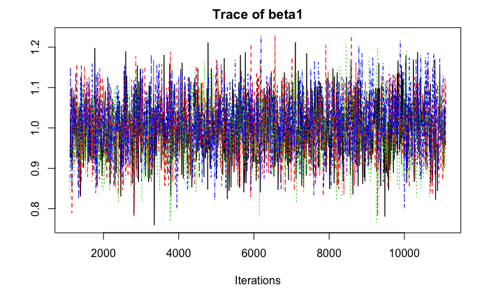

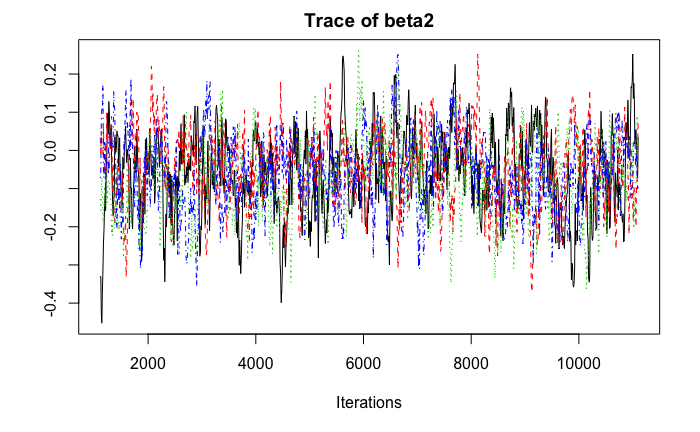

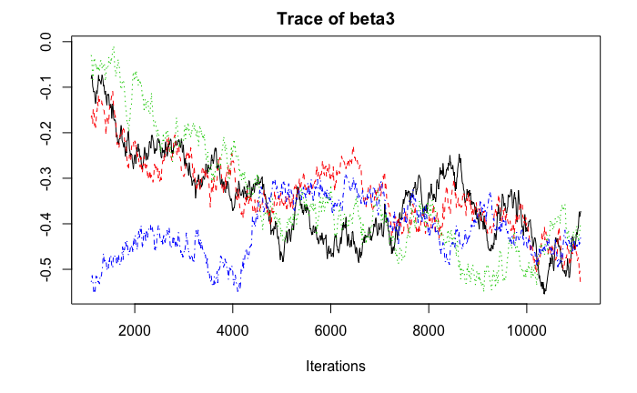

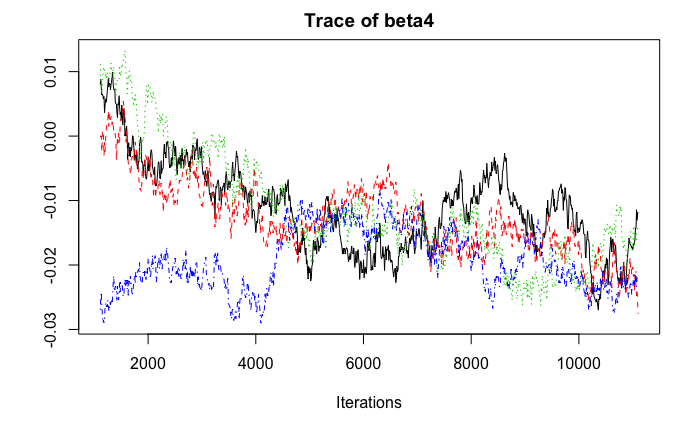

```r
traceplot(codaSamples)
```

Run gelman.diag which asseses convergence. Values less than 1.1 are typically seen as good, values above indicate that the chains have not converged. Run gelman.plot which shows how converged the chains are over the sampling period. These statistics indicate that beta1 and beta2 are converged. But beta3 and beta4 require more iterations until convergence. The plots indicate similar things except that the scales are different for each one. They cannot be compared to each other easily because of this.

```r
gelman.diag(codaSamples, confidence=.95)
```

```
Potential scale reduction factors:

      Point est. Upper C.I.
beta1       1.01       1.03
beta2       1.00       1.01
beta3       1.11       1.29
beta4       1.09       1.25

Multivariate psrf

2.82
```

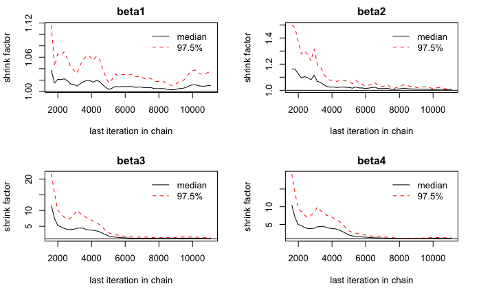

```r
gelman.plot(codaSamples, confidence=.95)
```